# 📝 Ensino normal 2026.1

2026-05-04 07:33:15

{{< toc hide_on=“xl” >}}

## Apresentação

Curso de Estatística e Probabilidade oferecido no formato presencial pela [UFSJ](http://ufsj.edu.br/), campus Alto Paraopeba ([CAP](http://ufsj.edu.br/cap/)), Ouro Branco/MG.

{{< icon name=“clock” pack=“fas” >}} 4 horas por semana, por 18 semanas

## Tópicos abordados

Definições gerais. Coleta, organização de dados. Medidas de posição. Medidas de dispersão. Probabilidades. Distribuições de probabilidade. Amostragem. Teoria da estimação. Teoria da decisão. Correlação e regressão linear simples.

{{< figure src=“/infografico/epaec/2026.1/epaec2026.1.png” title=“Visão Geral da disciplina de Estatística e Probabilidade (2026.1).” width=“400px” >}}

## Calendário e Cronograma

- Calendário

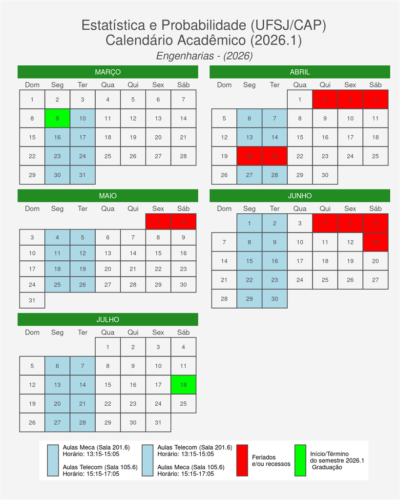

- [Cronograma de aulas](https://docs.google.com/document/d/15KR4SH_p_riW3XG5KjGLAdRIYUIIbVdwTJxHDmo1OyI/edit?usp=sharing): {{< gdocs src=“https://docs.google.com/document/d/15KR4SH_p_riW3XG5KjGLAdRIYUIIbVdwTJxHDmo1OyI/edit?usp=sharing” >}}

## Grupo de Whatsapp

- [*Link* (Só clicar!!!)](https://chat.whatsapp.com/FmX6soRW8qr4ecetCqZgA4)

## Notas

- Engenharia Mecatrônica ([Link](https://docs.google.com/spreadsheets/d/1CNum5I6j4lHZUNJy4GR8gyULJqAS14WjQkWpz0aCRW4/edit?usp=sharing))
- Engenharia de Telecomunicações (Link)

## Ementa

Nós usamos a ementa contida nos Projetos Pedagógicos de Cursos (PPCs) do CAP/UFSJ

{{< spoiler text=“Acesse a ementa do curso”>}} 1. DEFINIÇÕES GERAIS E TÉCNICAS DE SOMATÓRIO: - Introdução - Definições Gerais - Técnicas de somatório 2. COLETA, ORGANIZAÇÃO E APRESENTAÇÃO DE DADOS: - Introdução - Representação tabular - Representação gráfica 3. MEDIDAS DE POSIÇÃO: - Introdução - Média - Mediana - Moda 4. MEDIDAS DE DISPERSÃO: - Introdução - Amplitude total - Variância - Desvio Padrão - Coeficiente de Variação - Erro padrão da Média 5. PROBABILIDADES: - Conceitos básicos - Definições de probabilidades - Propriedades - Eventos independentes e probabilidade condicional - Teorema de Bayes - Função de probabilidade discreta - Função de probabilidade contínua - Função de distribuição de probabilidade acumulada - Esperança matemática e variância 6. DISTRIBUIÇÕES DE PROBABILIDADES: - Introdução - Distribuições discretas de probabilidades - Distribuições contínuas de probabilidades 7. AMOSTRAGEM: - Introdução - Amostragem não-probabilística e probabilística - Técnicas de amostragem probabilística 8. DISTRIBUIÇÃO DE AMOSTRAGEM: - Introdução - Distribuição de amostragem da média - Distribuição de amostragem de proporções - Distribuição de amostragem de diferença entre médias - Distribuições amostrais (qui-quadrado, t e F) 9. TEORIA DA ESTIMAÇÃO: - Introdução - Conceitos básicos - Tipos de estimativas - Propriedades de um estimador - Estimação por ponto - Estimação por intervalo: - Intervalo de confiança para a média - Intervalo de confiança para a variância - Intervalo de confiança para a diferença entre médias - Dimensionamento de amostras 10. TEORIA DA DECISÃO: - Introdução - Testes de hipóteses - Erros tipo I e II - Teste unilateral e bilateral - Passos para a construção de um teste de hipóteses - Teste de hipóteses para a média - Teste de hipóteses para a proporção - Teste de hipóteses para a variância - Teste de hipóteses para a diferença entre médias 11. CORRELAÇÃO E REGRESSÃO LINEAR SIMPLES: - Introdução - Correlação linear: - Coeficiente de correlação linear - Teste de hipóteses acerca do coeficiente de correlação linear - Regressão linear simples: - Modelo - Estimação dos parâmetros do modelo - Teste de hipóteses para o modelo de regressão - Medidas de adequação do modelo {{< /spoiler >}}

## Metodologia

Nossas aulas serão divididas de acordo com as 18 semanas de aula. As aulas serão expositivas e dialogadas com os alunos presencialmente, como também a inserção de aulas práticas usando o experimento da catapulta para conectar com os assuntos estudados em sala. Ainda, usaremos o ambiente R para o desenvolvimento das análises, mais especificamente, o pacote leem, constituída pela seguinte estratégia de ensino:

- Motivação:
  - Levantamento do conhecimento prévio dos alunos em relação ao tema;
  - Apresentação de algumas situações práticas para a compreensão dos tópicos a serem abordados;
  - Exposição dos objetivos da aula.
- Desenvolvimento:
  - Introdução ao assunto abordado;
  - Apresentação de definições e teoremas envolvidos;
  - Aplicação de softwares estatísticos, quando for pertinente;
  - Exemplos e aplicações na estatística e área do curso, do assunto abordado.

{{< spoiler text=“Detalhamento da metodologia”>}} Nossas aulas serão motivadas pelo experimento da catapulta. Por meio deste experimento geraremos todo o suporte para a obtenção de dados e assim, utilizar todas as técnicas estatística propostas na ementa da disciplina.

Iremos utilizar o [R](https://www.r-project.org/), [$\LaTeX$](https://www.latex-project.org/) [Quarto](https://quarto.org/), [Github](https://github.com/) e o pacote [leem](http://localhost:4321/project/leem/) {{< /spoiler >}}

## Avaliação

{{< spoiler text=“Segue um detalhamento das nossas avaliações”>}}

Faremos toda semana relatórios baseado em nossas aula teóricas e práticas, usando o [R](https://www.r-project.org/), [$\LaTeX$](https://www.latex-project.org/) e [Quarto](https://quarto.org/), integrando estes relatórios ao [Github](https://github.com/). Grande parte das análises estatísticas utilizadas serão desenvolvidas com o pacote [leem](http://localhost:4321/project/leem/).

A disciplina terá uma pontuação total de 10 pontos, sendo 80% distribuído aos relatórios, e 20% distribuídos aos nossos testes rápidos, trabalhos ou qualquer outra dinâmica que consiga obter informações da captação de conhecimento no momento da aula.

O discente que perder algum relatório ou atividade avaliativa referente aos 20% dos pontos informados anteriormente, deverá solicitar a coordenadoria de seu curso uma segunda chamada para tal atividade perdida, justificando a ausência da entrega. Sendo deferida pela coordação, faremos a segunda chamada de tal atividade.

{{< /spoiler >}}

## Bibliografia adotada para a disciplina

{{< spoiler text=“Bibliografia detalhada”>}}

{{< /spoiler >}}

## Material adotado

- Livro referência: [EPAEC](http://bendeivide.github.io/book-epaec/)
  - Sugestões e críticas sobre o livro podem ser enviadas para livrosdeben@gmail.com

{{< spoiler text=“Materiais complementares”>}} - [Estatística Básica aplicada às Ciências agrárias](https://bendeivide.github.io/books/estbasica/) - [R básico](https://bendeivide.github.io/books/eambr01/) - [Estatística Básica (Departamento de Estatística, UFPR)](http://leg.ufpr.br/~paulojus/estbas/) - [Estatística Aplicada (Tales Jesus Fernandes, UFLA)](http://github.com/talesjfer/Apostila-Estatistica-Aplicada) - [Resumo do Livro Estatística Básica (Daniel Furtado, UFLA)](http://repositorio.ufla.br/bitstream/1/41344/1/Gex112_0.pdf) - [Estatística e Probabilidade (UECE)](http://educapes.capes.gov.br/bitstream/capes/432207/2/Livro_Estatistica%20e%20Probabilidade.pdf) - [Estimação Estatística (Assis, et. al. 2021)](https://www.editorapantanal.com.br/ebooks/2021/estimacao-estatistica/ebook.pdf) - [Introdução à estatística com R (Eric Ferreira & Marcelo Oliveira )](http://www.unifal-mg.edu.br/bibliotecas/system/files/imce/EBR_Unifal.pdf) - [Introdução a linguagem R: seus fundamentos e práticas (Pedro Faria & João Parga)](https://www.researchgate.net/publication/345985082_Introducao_a_Linguagem_R_seus_fundamentos_e_sua_pratica) - [Teste de Hipóteses Estatísticas (Janilson Pinheiro de Assis et. al., UFERSA)](https://livraria.ufersa.edu.br/wp-content/uploads/sites/165/2020/08/testes-de-hipoteses-estatisticas-edufersa.pdf) - [Glossário de Estatística (Janilson Pinheiro de Assis, UFERSA)](https://livraria.ufersa.edu.br/wp-content/uploads/sites/165/2019/07/Glossario-de-Estatistica_2019-1.pdf) - [Canal Ciência Estatística](https://www.youtube.com/channel/UCoL7IgyKRZ6JBog71LnoGzA) - [Estatística e Probabilidade: Exercícios (Assis et. al., 2023)](https://editorapantanal.com.br/ebooks/2023/probabilidade-e-estatistica-exercicios/ebook.pdf) {{< /spoiler >}}

## -> Modelo de Relatório R para *Web*

Acesse o link

## Lista alunos

**Engenharia Mecatrônica**

- [🎓 DANIEL DE FREITAS ALBERNAZ JUNIOR e 🎓 MARCOS VINICIUS DE OLIVEIRA FARIA](https://marcosvinicius31619.github.io/relatorio-estprob/)
- [🎓 IAN PEREIRA VENTURATO e 🎓 RAFAEL ROBERTO ROCHA DE OLIVEIRA](https://ianventurato.github.io/relatorio-estprob/)
- [🎓 IGOR PEREIRA VITAL e 🎓 LUCAS WILLIAM ENDRINGER MOURA](https://igorpereiravital.github.io/relatorios/)
- [🎓 LUIZ GUSTAVO ALVES CARVALHO](https://luizgustavoa.github.io/relatorio-estprob/)
- [🎓 MARIA EDUARDA MOTTA ROSA e 🎓 JOAO PEDRO DELPASSO CANAVAL](https://jpdcjpdc.github.io/relatorio-estprob/)
- [🎓 WADMILSON COSTA DA FONSECA E CRUZ](https://wadmilson.github.io/relatorio-estprob/)

**Engenharia de Telecomunicações**

- [🎓 EMILLY BEATRIZ DE LIMA](https://emillymontilla.github.io/relatorio-estprob/)
- [🎓 LUCAS REIS OLIVEIRA DE ANDRADE](https://gitlucasandrade.github.io/relatorio-estprob/)
- [🎓 LUIZ GUSTAVO DOS SANTOS](https://luizsantos13.github.io/rel.est.prob/)
- [🎓 NICOLAS GONÇALVES CARDOSO GUIMARÃES](https://nicolasgoncalves-web.github.io/relatorio-estprob2/)
- [🎓 SARAH OLIVEIRA RAMALHO](https://sararamalho.github.io/relatorio-estprob/)
- [🎓 VITOR THEODORO OLIVEIRA VIANA](https://vitortheo.github.io/relatorio-estprob/)

## Lista de exercícios e relatórios

- **Listas**

{{< spoiler text=“📌 Lista de Exercício 1 (Clique!) - 30/03/2026”>}}

- Entrega: Via portal didático
- Formato: Escrito a mão (Digitalizado)
- 30/03/2026 Antes do início do horário de aula

> **OBJETIVO**

> Tabular os dados do [Exemplo 2.1](https://bendeivide.github.io/book-epaec/cap02.html#ex:Challanger1986) do livro [EPAEC (Capítulo 2)](https://bendeivide.github.io/book-epaec/cap02.html), mostrando de forma analítica, como também usando o R, mas especificamente o pacote leem. A entrega deve ser feita a mão, digitalizada posteriormente e convertida para PDF, anexando na referida lista. Para mostra via R, basta apresentar os passos de como fazer, não precisando escrever os dados.

{{}}

{{< spoiler text=“📌 Lista de Exercício 2 (Clique!) - 06/04/2026”>}}

- Entrega: Via portal didático
- Formato: Escrito a mão (Digitalizado)
- 06/04/2026 Antes do início do horário de aula

> **OBJETIVO**

> Fazer os [exercícios do Capítulo 4 (EPAEC)](https://bendeivide.github.io/book-epaec/cap04.html#exerc%C3%ADcios-propostos)

> **DATA DA ENTREGA:**
> - Até às 13:15 do dia 06/04/2026 (Engenharia Mecatrônica)
> - Até às 15:15 do dia 06/04/2026 (Engenharia de Telecomunicações)

{{}}

{{< spoiler text=“📌 Lista de Exercício 3 (Clique!) - 14/04/2026”>}}

- Entrega: Via portal didático
- Formato: Escrito a mão (Digitalizado)
- 14/04/2026 Antes do início do horário de aula

> **OBJETIVO**

> Apresentar as Leis de Morgan, prová-las e apresentar exemplos.

> **DATA DA ENTREGA:**
> - Até às 13:15 do dia 14/04/2026 (Engenharia de Telecomunicações)
> - Até às 15:15 do dia 14/04/2026 (Engenharia Mecatrônica)

{{}}

- **Relatórios**

{{< spoiler text=“📝 Como os relatórios serão avaliados?”>}}

Seguindo as seguintes indagações:

| Indagação |
| --- |
| 1. Entregou no prazo? |
| 2. Precisou de correção? |
| 2.1 Foi corrigido? |
| 3. Relatório organizado? |
| 4. Coerente com o que foi pedido? |
| 5. Abordou todos os tópicos solicitados? |
| 6. Aprofundou o assunto? |
| 7. Código R formatado? |
| 8. Tem exemplos de aplicação? |
| 9. Código R Markdown formatado? |
| 10. Tem referências? |
| 11. Referências formatadas? |
| 12. Introdução? |
| 13. Objetivos? |
| 14. Metodologia? |
| 15. Resultados e Discussão? |
| 16. Conclusão ou considerações finais? |
| 17. O trabalho atingiu os objetivos? |

As perguntas se enquadrarão em:

| Não (0%) | Pouco (25%) | Parcial(50%) | Quase lá (75%) | Sim (100%) |
| --- | --- | --- | --- | --- |
| [ ] | [ ] | [ ] | [ ] | [ ] |

A pergunta 2 seguirá a seguinte escala:

| Não (0%) | Pouco (-10%) | Parcial(-20%) | Metade (-50%) | Mais da metade (-75%) |
| --- | --- | --- | --- | --- |
| [ ] | [ ] | [ ] | [ ] | [ ] |

O item 2.1, auxiliará a recuperar a nota perdida em 2.

{{}}

{{< spoiler text=“🗒 Relatório 1 (Clique!) - 31/03/2026”>}}

- Entrega: Via Github
- Formato: [Modelo de Relatório](https://github.com/bendeivide/relatorio-estprob/archive/refs/heads/master.zip)
- 31/03/2026 Antes do início do horário de aula

> **OBJETIVO**

> Descreva o experimento da catapulta, realizado em sala de aula, apresentando os níveis dos fatores utilizados no experimento (O-, A+, B+, A-) para medir a distância percorrida pela bolinha; tabule os valores obtidos; mostre possíveis problemas que podem ter acontecido na realização do experimento; use os podcasts, o material descrito nesta página sobre o experimento, explorando também as IAs para lhe auxiliarem na escrita do material. Lembre-se que ao final, você é responsável pelo que escreve, portanto, *entenda tudo que está sendo escrito para a preparação da Defesa do relatório, caso seja solicitado.*

{{}} {{< spoiler text=“🗒 Relatório 2 (Clique!) - 03/04/2026”>}}

- Entrega: Via Github
- Formato: HTML
- 03/04/2026 17h

> **OBJETIVO**

> Realizar um introdução ao R, fundamentado nas 8 primeiras aulas do curso R Básico 2024.

> **DATA DA ENTREGA:**
> - Até às 17:05 do dia 03/04/2026

{{}}

{{< spoiler text=“🗒 Relatório 3 (Clique!) - 14/04/2026”>}}

- Entrega: Via Github
- Formato: HTML
- 14/04/2026 13h

> **OBJETIVO**

> Usar os dados do experimento da catapulta, realizado em sala de aula: - Divisão de dois grandes grupos (alunos); - Cada grupo irá realizar o experimento da catapulta, realizando-o 40 vezes; isto é, coletando 40 observações da distância do arremeço da bolinha; - Cada grupo apresenta uma configuração diferente entre as fontes de variação (A+, A-, O-, B+); - Proceder na descrição desses dados baseado na tabulação e apresentação gráfica; - obter medidas de posição e de dispersão; fazer com agrupamente e sem agrupamento, discutindo a diferença entre esses resultados; - Adicionalmente, estude sobre assimetria e curtose e calcule estes valores ao conjunto de dados, apresentando justificativas da importância dessas medidas à descrição dos dados; - Use o pacote leem; - Lembre-se de descrever cada seção do seu trabalho, dando detalhes sobre os passos do desenvolvimento de seu relatório; - Apresente fotos da execução do trabalho; - Apresente possíveis falhas de execução do experimento, caso tenha havido.

> **Todo o processo de cálculo deve ser realizado de forma analítica e via leem!!**

> **DATA DA ENTREGA: 14/04/2026, 13h**

{{}}

## Experimentos para as aulas práticas

{{< spoiler text=“⚗️ Experimento da catapulta”>}}

O experimento da catapulta consiste no lançamento de uma bolinha por meio de um dispositivo mecânico, variando-se condições como a posição do elástico, posição da bolinha e o ângulo de disparo. O objetivo é analisar como essas variáveis podem ou não influenciar a distância percorrida pela bolinha.

Ou melhor,

> “Se lançarmos uma mesma bolinha várias vezes com essa catapulta, sob as mesmas condições iniciais, ela sempre cairá no mesmo lugar?”

Mesmo sob condições controladas, observa-se que os resultados não são idênticos, evidenciando a presença de variabilidade experimental. Assim, este experimento constitui um contexto adequado para a aplicação de técnicas estatísticas que abordaremos em nosso curso.

O experimento da catapulta pode ser ilustrado na Figura 1.

{{< figure src=“/imagens/catapulta/exp_catapulta.png” title=“Figura 1: Experimento da catapulta.” width=“400px” style=“text-align: center;”>}}

A distância percorrida pela bolinha depende basicamente de:

- **energia armazenada no sistema** (elástico)
- **ângulo de lançamento**
- **geometria do mecanismo**

Os pontos **O-, A+, A- e B+** controlam exatamente esses aspectos. A Figura 2 apresenta a catapulta utilizada no experimento em sala de aula.

{{< figure src=“/imagens/catapulta/catapulta.jpg” title=“Figura 2: Catapulta utilizada em sala de aula.” width=“400px” style=“text-align: center;”>}}

### ⚙️ 1. Posição **A+** (tensão do elástico – maior intensidade)

- Local onde o elástico é fixado mais “esticado”
- Representa **maior deformação do elástico**

{{< figure src=“/imagens/catapulta/fator_amais.jpg” title=“Figura 3: Fator A+.” width=“400px” style=“text-align: center;”>}}

#### 🔬 Efeito físico:

- Aumenta a **energia potencial elástica**
- Gera maior velocidade inicial da bolinha

#### 📊 Impacto na distância:

- Tendência de **maior alcance**
- Porém:
  - pode aumentar a variabilidade (lançamentos mais “sensíveis”)

### ⚙️ 2. Posição **A-** (tensão do elástico – menor intensidade)

- Posição com menor estiramento do elástico

{{< figure src=“/imagens/catapulta/fator_amenos.jpg” title=“Figura 4: Fator A-.” width=“400px” style=“text-align: center;”>}}

#### 🔬 Efeito físico:

- Menor energia armazenada
- Menor velocidade de lançamento

#### 📊 Impacto na distância:

- **Menor alcance médio**
- Em geral:
  - maior controle
  - menor variabilidade

### ⚙️ 3. Posição **B+** (ajuste do ângulo/curso do braço)

- Relacionada ao limite de deslocamento do braço da catapulta
- Atua como um **batente ou regulador do ângulo final**

{{< figure src=“/imagens/catapulta/fator_bmais.jpg” title=“Figura 5: Fator B+.” width=“400px” style=“text-align: center;”>}}

#### 🔬 Efeito físico:

- Define o **ângulo de saída da bolinha**
- Influencia o tempo de voo

#### 📊 Impacto na distância:

- Ângulos próximos de ~45° → maior alcance (ideal teórico)
- Ângulos muito baixos → bola “rasteira”
- Ângulos muito altos → bola sobe mais, mas percorre menos distância horizontal

### ⚙️ 4. Posição **O-** (ponto de referência/apoio superior)

- Atua como referência estrutural do braço
- Pode influenciar o alinhamento ou ponto de giro

{{< figure src=“/imagens/catapulta/fator_omenos.jpg” title=“Figura 6: Fator O-.” width=“400px” style=“text-align: center;”>}}

#### 🔬 Efeito físico:

- Afeta a **geometria do movimento**
- Pode alterar levemente:
  - o ângulo inicial
  - o comportamento do braço

#### 📊 Impacto na distância:

- Influência mais **indireta**
- Atua em conjunto com A e B
- Pode afetar a **reprodutibilidade** dos lançamentos

### 🧠 Integração das variáveis

A distância não depende de um fator isolado, mas da combinação:

$$\text{Distância} = f(\text{tensão do elástico}, \text{ângulo},
\text{geometria}) + \varepsilon$$

Ou, de forma mais didática:

- **A+ / A- → controla a força**
- **B+ → controla o ângulo**
- **O- → estabiliza o sistema**

{{< /spoiler >}}

## Aulas

{{< spoiler text=“🎓 Aula 1”>}}

{{< icon name=“pen-fancy” pack=“fas” >}} **Temas:** Apresentação do curso e Definições gerais da estatística e técnicas de somatório ([Capítulo 1](https://bendeivide.github.io/book-epaec/cap01.html))

{{< icon name=“book-reader” pack=“fas” >}} [**Plano de aula**](https://docs.google.com/document/d/1GCzMX9DeFUFxXrr5kvXhXjXmHl7j0OhrM3HFt4nolpw/edit?usp=sharing)

{{< icon name=“eye” pack=“fas” >}} **Apresentação:** Aula 01

{{< icon name=“clock” pack=“fas” >}} **Tempo:** 1h 50min.

{{< icon name=“book” pack=“fas” >}} **Livro EPAEC:** [Capítulo 1](https://bendeivide.github.io/book-epaec/cap01.html)

{{< icon name=“headphones” pack=“fas” >}} **Podcast**

{{< spoiler text=“🎙 Podcast 01 (NotebookLM - 2026.1) - Como a estatística transforma dados em decisoes”>}}

{{< audio src=“/podcast/epaec/2026.1/notebooklm/podcast01_Como_a_estatística_transforma_dados_em_decisoes.mp3” >}}

{{< spoiler text=“✏️ Descrição do Podcast”>}}

Este podcast foi desenvolvido por meio da *IA Notebooklm* com edição de Ben Dêivide, baseado no vídeo [RES0001 - Definições Gerais da Estatística](https://www.youtube.com/watch?v=Ibc6BUt3jbc).

{{< /spoiler >}}

{{< /spoiler >}}

{{< spoiler text=“🎙 Podcast 02 (NotebookLM - 2026.1) - Como a estatística decifra a realidade oculta”>}}

{{< audio src=“/podcast/epaec/2026.1/notebooklm/podcast02_Como_a_estatística_decifra_a_realidade_oculta.mp3” >}}

{{< spoiler text=“✏️ Descrição do Podcast”>}}

Este podcast foi desenvolvido por meio da *IA Notebooklm* com edição de Ben Dêivide, baseado no vídeo [RES0001 - Definições Gerais da Estatística](https://www.youtube.com/watch?v=Ibc6BUt3jbc).

{{< /spoiler >}}

{{< /spoiler >}}

{{< spoiler text=“🎙 Podcast EP-ER#01 (2021.2) - Definições Gerais da Estatística”>}}

[interactive chart not shown]

{{< spoiler text=“✏️ Descrição do Podcast”>}}

Este podcast foi desenvolvido na disciplina de Estatística e Probabilidade, no período remoto em 2021.2.

{{< /spoiler >}}

{{< /spoiler >}}

{{< spoiler text=“🎙 Podcast 01 (Por Elisa Najla, 2022.2) - Definições Gerais da Estatística”>}}

[video not shown]

{{< spoiler text=“✏️ Descrição do Podcast”>}}

Este podcast foi desenvolvido na disciplina de Estatística e Probabilidade, no período de 2022.1, por Elisa Najla, aluna de Engenharia de Telecomunicações (UFSJ). Mais podcasts, acesse [Youtube/bendeivide](https://www.youtube.com/watch?v=D1m6PC53BXU&list=PL-20Z1XFWKR3M4laONv5FlvyKF8tLAHE4).

{{< /spoiler >}}

{{< /spoiler >}}

{{< icon name=“r-project” pack=“fab” >}} *Script* Aula 1

{{< icon name=“brain” pack=“fas” >}} **Infográfico**

{{< spoiler text=“🧠 Infográfico 01 (NotebookLM) - Definições Gerais da Estatística”>}}

{{< figure src=“/infografico/epaec/2026.1/info01_Definicoes_gerais_da_estatistica.png” title=“Mapa Mental 01 (NotebookLM) - Definições Gerais da Estatística.” width=“400px” >}}

{{< /spoiler >}}

{{< icon name=“youtube” pack=“fab” >}} **Videoaulas de semestres anteriores**

- 🎥 [Definições gerais da estatística](https://youtu.be/OrgaM1J4w3I?si=i2W2wusUG-nn2nS0)
- 🎥 [Resumo sobre Definições gerais da estatística](https://youtu.be/Ibc6BUt3jbc?si=lpMHRMVDCyRxXS9q)
- 🎥 [Ensino Remoto 2021.1 - Apresentação da disciplina de Estatística e Probabilidade](https://youtu.be/l0JjW-E9jco?si=FECgnSxU9cCmHvrV)
- 🎥 [Ensino Remoto 2021.1 - Definições gerais da Estatística e organização de dados](https://www.youtube.com/live/bVObtgCFISs?si=VIPBV0uHAuARIz9l)
- 🎥 [População, Amostra e Variável](https://youtu.be/xvORKHMVUr8?si=s8nakBWREHHCD9iS)
- 🎥 [Técnicas de Somatório](https://youtu.be/tWCxCyZZHes?si=DIxL0OszO93nrk0n)

{{< /spoiler >}}

{{< spoiler text=“🎓 Aula 2”>}}

{{< icon name=“pen-fancy” pack=“fas” >}} **Temas:** Introdução ao R e Aula Prática 01

{{< icon name=“book-reader” pack=“fas” >}} [**Plano de aula**](https://docs.google.com/document/d/1cW42miXDot1Bpa5OaF5NAC8bWRJDIP2dUqWaOxETmeQ/edit?usp=sharing)

{{< icon name=“eye” pack=“fas” >}} **Apresentação:** Aula 02

{{< icon name=“clock” pack=“fas” >}} **Tempo:** 1h 50min.

{{< icon name=“book” pack=“fas” >}} **Livro R Básico:** [Capítulo 2](https://bendeivide.github.io/book-eambr01/hist%C3%B3ria-e-instala%C3%A7%C3%A3o-do-r.html), [Capítulo 3](https://bendeivide.github.io/book-eambr01/como-o-r-trabalha.html)

{{< icon name=“headphones” pack=“fas” >}} **Podcast**

{{< spoiler text=“🎙 Podcast 04 (NotebookLM - 2026.1) - Estatística e variabilidade no experimento da catapulta”>}}

{{< audio src=“/podcast/epaec/2026.1/notebooklm/podcast04_Estatistica_e_variabilidade_no_experimento_da_catapulta.mp3” >}}

{{< spoiler text=“✏️ Descrição do Podcast”>}}

Este podcast foi desenvolvido por meio da *IA Notebooklm* com edição de Ben Dêivide, baseado na descrição do experimento da catapulta na seção  
Experimentos para as aulas práticas.

{{< /spoiler >}}

{{< /spoiler >}}

{{< spoiler text=“🎙 Podcast 05 (NotebookLM - 2026.1) - O que acontece na memória do R”>}}

{{< audio src=“/podcast/epaec/2026.1/notebooklm/podcast05_O_que_acontece_na_memoria_do_R.mp3” >}}

{{< spoiler text=“✏️ Descrição do Podcast”>}}

Este podcast foi desenvolvido por meio da *IA Notebooklm* com edição de Ben Dêivide, nas aulas 02, 04 e 05 do curso [R Básico 2024](https://bendeivide.github.io/courses/ear/rbasico2024/#aulas).

{{< /spoiler >}}

{{< /spoiler >}}

{{< icon name=“r-project” pack=“fab” >}} *Script* Aula 2

{{< icon name=“brain” pack=“fas” >}} **Infográfico**

{{< spoiler text=“🧠 Infográfico 02 (NotebookLM) - Primeiros passos com o R e RStudio”>}}

{{< figure src=“/infografico/epaec/2026.1/info02_Primeiros_passos_com_R_e_RStudio.png” title=“Infográfico 02 (NotebookLM) - Primeiros passos com o R e RStudio.” width=“400px” >}}

{{< /spoiler >}}

{{< icon name=“book-reader” pack=“fas” >}} **Material para consulta:**

- [R Básico - Capítulo 2](https://bendeivide.github.io/book-eambr01/hist%C3%B3ria-e-instala%C3%A7%C3%A3o-do-r.html)
- [R Básico - Capítulo 3](https://bendeivide.github.io/book-eambr01/como-o-r-trabalha.html)
- <a href=“{{< relref”courses/EAR/Rbasico/index”>}}” target=“_blank”> Curso EAR: R básico
- <a href=“{{< relref”#experimentos”>}}” target=“_blank”> Experimento da catapulta

{{< icon name=“youtube” pack=“fab” >}} **Videoaulas de semestres anteriores**

- 🎥 [Passos iniciais para a utilização do R e do RStudio](https://youtu.be/KryehEXgGF8?si=ErToSRKg8dVq9cjl)
- 🎥 [Como o R trabalha?](https://www.youtube.com/live/yO8qKud3sIk?si=bIxLQQe_eszQrbay)
- 🎥 [Comandos no R e Ambiente Global](https://youtu.be/iI9Vx7dzOfo?si=AoZTTYNMCgHqCSlH)

{{< /spoiler >}}

{{< spoiler text=“🎓 Aula 3”>}}

{{< icon name=“pen-fancy” pack=“fas” >}} **Temas:** Introdução ao R (Parte II) e [Capítulo 2](https://bendeivide.github.io/book-epaec/cap02.html)

{{< icon name=“book-reader” pack=“fas” >}} [**Plano de aula**](https://docs.google.com/document/d/1zx4gyOXrmkusMsP3o0X8exYTWH7ln5GLUi4-q1nSBpg/edit?usp=sharing)

{{< icon name=“eye” pack=“fas” >}} **Apresentação:** Aula 03

{{< icon name=“clock” pack=“fas” >}} **Tempo:** 1h 50min.

{{< icon name=“book” pack=“fas” >}} **Livro EPAEC:** [Capítulo 2](https://bendeivide.github.io/book-epaec/cap02.html)

{{< icon name=“headphones” pack=“fas” >}} **Podcast**

{{< spoiler text=“🎙 Podcast 03 (NotebookLM - 2026.1) - Como dar sentido ao caos dos dados”>}}

{{< audio src=“/podcast/epaec/2026.1/notebooklm/podcast03_Como_dar_sentido_ao_caos_dos_dados.mp3” >}}

{{< spoiler text=“✏️ Descrição do Podcast”>}}

Este podcast foi desenvolvido por meio da *IA Notebooklm* com edição de Ben Dêivide, baseado no vídeo [Tabulação e organização de dados](https://youtu.be/wdXJ_CzMdXI?si=laEZUuPksF--vkyR) e o [Capítulo 2](https://bendeivide.github.io/book-epaec/cap02.html) do EPAEC.

{{< /spoiler >}}

{{< /spoiler >}}

{{< spoiler text=“🎙 Podcast 02 (Por Elisa Najla, 2022.2) - Coleta, organização e apresentação de dados”>}}

[video not shown]

{{< spoiler text=“✏️ Descrição do Podcast”>}}

Este podcast foi desenvolvido na disciplina de Estatística e Probabilidade, no período de 2022.1, por Elisa Najla, aluna de Engenharia de Telecomunicações (UFSJ). Mais podcasts, acesse [Youtube/bendeivide](https://www.youtube.com/watch?v=D1m6PC53BXU&list=PL-20Z1XFWKR3M4laONv5FlvyKF8tLAHE4).

{{< /spoiler >}}

{{< /spoiler >}}

{{< spoiler text=“🎙 Podcast 06 (Notebooklm - 2026.1) - A Engenharia por trás do R”>}}

{{< audio src=“/podcast/epaec/2026.1/notebooklm/podcast06_A_engenharia_por_tras_do_R.mp3” >}}

{{< spoiler text=“✏️ Descrição do Podcast”>}}

Este podcast foi desenvolvido por meio da *IA Notebooklm* com edição de Ben Dêivide, baseado nos vídeos [R Básico 2024 | Aula 08 - Objetos e Estrutura de dados](https://www.youtube.com/watch?v=wl_TsLblYoU) e [R Básico 2024 | Aula 15 - Funções](https://www.youtube.com/watch?v=1EfnPu_rjDQ).

{{< /spoiler >}}

{{< /spoiler >}}

{{< icon name=“r-project” pack=“fab” >}} [*Script* Aula 3](https://raw.githubusercontent.com/bendeivide/bendeivide.github.io/main/docs/epaec/2024.1/r-scripts/aula03.R)

{{< icon name=“brain” pack=“fas” >}} **Infográfico**

{{< spoiler text=“🧠 Infográfico 03 (NotebookLM - 2026.1) - Coleta e organização de dados”>}}

{{< figure src=“/infografico/epaec/2026.1/info03_Coleta_organizacao_dados.png” title=“Infográfico 03 (NotebookLM - 2026.1) - Coleta e organização de dados.” width=“400px” >}}

{{< /spoiler >}}

{{< spoiler text=“🧠 Infográfico 04 (NotebookLM - 2026.1) - Fundamentos do R: O Universo de Objetos e Funções”>}}

{{< figure src=“/infografico/epaec/2026.1/info04_fundR_obj_func.png” title=“Infográfico 04 (NotebookLM - 2026.1) - Fundamentos do R: O Universo de Objetos e Funções.” width=“400px” >}}

{{< /spoiler >}}

{{< icon name=“book-reader” pack=“fas” >}} **Material para consulta**

- <a href=“{{< relref”courses/epaec/remoto/index” >}}” target=“_blank”>Estatística e Probabilidade (Ensino Remoto)
- <a href=“{{< relref”courses/EAR/Rbasico/index”>}}” target=“_blank”> Curso EaAR: R básico
- <a href=“{{< relref”courses/epaec/exerresolvidos/index”>}}” target=“_blank”>Exercícios resolvidos

{{< icon name=“youtube” pack=“fab” >}} **Videoaulas de semestres anteriores**

- 🎥 [Tabulação e Organização de Dados](https://youtu.be/wdXJ_CzMdXI?si=hrp_4f5-ctmmVQ__)
- 🎥 [Estatística e Probabilidade (ER - 2021.2) - Aula 01: Definições gerais da Estatística e organização de dados](https://www.youtube.com/live/bVObtgCFISs?si=6idNqaEOZ5LKJw5K)
- 🎥 [Estatística e Probabilidade (ER - 2021.2) - Aula 02: Exercícios resolvidos aos temas inseridos na descrição](https://www.youtube.com/live/DZ4PzyY5YYg?si=wcMPr_7cms8l4zsm)

{{< /spoiler >}}

{{< spoiler text=“🎓 Aula 4”>}}

{{< icon name=“pen-fancy” pack=“fas” >}} **Temas:** Aula Prática 02 - Cap. 01 e 02

{{< icon name=“book-reader” pack=“fas” >}} [**Plano de aula**](https://docs.google.com/document/d/1MM002uOsIMQg1et6_tUxF14SSvfvdrr_JLqlKl-dvEc/edit?usp=sharing)

{{< icon name=“eye” pack=“fas” >}} **Apresentação:** Aula 04

{{< icon name=“clock” pack=“fas” >}} **Tempo:** 1h 50min.

{{< icon name=“book” pack=“fas” >}} **Livro EPAEC:** [Capítulo 1](https://bendeivide.github.io/book-epaec/cap01.html), [Capítulo 2](https://bendeivide.github.io/book-epaec/cap02.html)

**Configuração do experimento**

Para detalhes sobre os níveis, acesse: Experimento para aulas práticas

{{< spoiler text=“🔭 Desenho experimental - Eng. Tel.”>}}

Níveis dos fatores experimentais:

- **O-**: nível II
- **A+**: nível III
- **B+**: nível 90°
- **A-**: nível IV

{{< /spoiler >}}

{{< spoiler text=“🔭 Desenho experimental - Eng. Mec.”>}}

Níveis dos fatores experimentais:

- **O-**: nível III
- **A+**: nível II
- **B+**: nível 100°
- **A-**: nível II

{{< /spoiler >}}

{{< icon name=“r-project” pack=“fab” >}} {{% staticref “/epaec/2026.1/r-scripts/aula04.R” “newtab” %}}Script Aula 04 (Geral).R{{% /staticref %}}, {{% staticref “/epaec/2026.1/telecom/EPAEC2026.1_TELECOM_AP02.R” “newtab” %}}Script Aula 04 - AP02 (Eng. Tel).R{{% /staticref %}}, {{% staticref “/epaec/2026.1/meca/EPAEC2026.1_MECA_AP02.R” “newtab” %}}Script Aula 04 - AP02 (Eng. Mec).R{{% /staticref %}}

{{< icon name=“book-reader” pack=“fas” >}} **Material para consulta**

- <a href=“{{< relref”courses/epaec/remoto/index” >}}” target=“_blank”>Estatística e Probabilidade (Ensino Remoto)
- <a href=“{{< relref”courses/EAR/Rbasico/index”>}}” target=“_blank”> Curso EAR: R básico
- <a href=“{{< relref”courses/epaec/exerresolvidos/index”>}}” target=“_blank”>Exercícios resolvidos

{{< /spoiler >}}

{{< spoiler text=“🎓 Aula 5”>}}

{{< icon name=“pen-fancy” pack=“fas” >}} **Temas:** Como desenvolver Relatórios Web

{{< icon name=“book-reader” pack=“fas” >}} [**Plano de aula**](https://docs.google.com/document/d/1cQZ4wYM14FhsYVRSH2HikTn_5PiwibTU8i1yH3p-DSY/edit?usp=sharing)

{{< icon name=“clock” pack=“fas” >}} **Tempo:** 1h 50min.

{{< icon name=“headphones” pack=“fas” >}} **Podcast**

{{< spoiler text=“🎙 Podcast 08 (NotebookLM - 2026.1) - O Professor de estatística baniu o PDF”>}}

{{< audio src=“/podcast/epaec/2026.1/notebooklm/podcast08_O_professor_de_estatística_baniu_o_PDF.mp3” >}}

{{< spoiler text=“✏️ Descrição do Podcast”>}}

{{< /spoiler >}}

{{< /spoiler >}}

{{< icon name=“r-project” pack=“fab” >}} [Projeto RStudio - Relatório](https://github.com/bendeivide/relatorio-estprob/archive/refs/heads/master.zip)

{{< icon name=“brain” pack=“fas” >}} **Infográfico**

{{< spoiler text=“🧠 Infográfico 05 (NotebookLM - 2026.1) - Guia prático: Criando e publicando relatórios *web* com R/RStudio e Github”>}}

{{< figure src=“/infografico/epaec/2026.1/info05_relatorios_web.png” title=“Guia prático: Criando e publicando relatórios *web* com R/RStudio e Github.” width=“400px” >}}

{{< /spoiler >}}

{{< icon name=“book-reader” pack=“fas” >}} **Material para consulta**

- <a href=“{{< relref”courses/epaec/modrel/index” >}}” target=“_blank”>Modelo de relatório

{{< icon name=“youtube” pack=“fab” >}} **Videoaulas de semestres anteriores**

- 🎥 [Relatórios para páginas web (R & GitHub)](https://youtu.be/sY4eo3eUR-c?si=YeHybeDIHEx72ODl)
- 🎥 [Relatórios para páginas web (R & GitHub) - Parte II](https://youtu.be/nhh323kMWqo?si=4U8YCyUACdvxNwmG)

{{< /spoiler >}}

{{< spoiler text=“🎓 Aula 6”>}}

{{< icon name=“pen-fancy” pack=“fas” >}} **Tema** Aula prática 03 e Medidas de Posição ([Capítulo 3](https://bendeivide.github.io/book-epaec/cap02.html))

{{< icon name=“eye” pack=“fas” >}} **Apresentação:** Aula 06 {{< icon name=“book-reader” pack=“fas” >}} [**Plano de aula**](https://docs.google.com/document/d/1kQQYkjs34f3zhqlKdQc6DkDK81Xwa3U0Ht_2T9Ce1hs/edit?usp=sharing)

{{< icon name=“book” pack=“fas” >}} **Livro EPAEC:** [Capítulo 3](https://bendeivide.github.io/book-epaec/cap03.html)

{{< icon name=“clock” pack=“fas” >}} **Tempo:** 1h 50min.

{{< icon name=“headphones” pack=“fas” >}} **Podcast**

{{< spoiler text=“🎙 Podcast 9 (NotebookLM - 2026.1) - Por que a média pode enganar você?”>}}

{{< audio src=“/podcast/epaec/2026.1/notebooklm/podcast09_Por_que_a_media_pode_enganar_voce.mp3” >}}

{{< spoiler text=“✏️ Descrição do Podcast”>}}

Este podcast foi desenvolvido por meio da *IA Notebooklm* com edição de Ben Dêivide, baseado no vídeo [Estatística e Probabilidade (ER - 2021) - Aula 04: Medidas de posição e Medidas de dispersão](https://www.youtube.com/live/s-yrirgOA8A?si=VLn3adrp6sAK0VJw) e [Capítulo 3 - EPAEC](https://bendeivide.github.io/book-epaec/cap03.html). {{< /spoiler >}}

{{< /spoiler >}}

{{< icon name=“brain” pack=“fas” >}} **Infográfico**

{{< spoiler text=“🧠 Infográfico 06 (NotebookLM - 2026.1) - Guia das medidas de posição”>}}

{{< figure src=“/infografico/epaec/2026.1/info06_guia_medidas_posicao.png” title=“Infográfico 06 (NotebookLM - 2026.1) - Guia das medidas de posição.” width=“400px” >}}

{{< /spoiler >}}

{{< icon name=“book-reader” pack=“fas” >}} **Material para consulta**

- <a href=“{{< relref”courses/epaec/remoto/index” >}}” target=“_blank”>Estatística e Probabilidade (Ensino Remoto)
- <a href=“{{< relref”courses/EAR/Rbasico/index”>}}” target=“_blank”> Curso EAR: R básico
- <a href=“{{< relref”courses/epaec/exerresolvidos/index”>}}” target=“_blank”>Exercícios resolvidos

{{< icon name=“youtube” pack=“fab” >}} **Videoaulas de semestres anteriores**

- 🎥 [Estatística e Probabilidade (ER - 2021) - Aula 04: Medidas de posição e Medidas de dispersão](https://www.youtube.com/live/s-yrirgOA8A?si=VLn3adrp6sAK0VJw)

{{< /spoiler >}}

{{< spoiler text=“🎓 Aula 7”>}}

{{< icon name=“pen-fancy” pack=“fas” >}} **Tema** Medidas de Dispersão ([Capítulo 4](https://bendeivide.github.io/book-epaec/cap04.html))

{{< icon name=“eye” pack=“fas” >}} **Apresentação:** Aula 07 {{< icon name=“book-reader” pack=“fas” >}} [**Plano de aula**](https://docs.google.com/document/d/1GuXPho9a_uyBs-RvNV9QCBMArJHmfJpSG6FdLsL9Zjc/edit?usp=sharing)

{{< icon name=“book” pack=“fas” >}} **Livro EPAEC:** [Capítulo 4](https://bendeivide.github.io/book-epaec/cap04.html)

{{< icon name=“clock” pack=“fas” >}} **Tempo:** 1h 50min.

{{< icon name=“headphones” pack=“fas” >}} **Podcast**

{{< spoiler text=“🎙 Podcast 10 (NotebookLM - 2026.1) - Simbiose entre medidas de posição e dispersão”>}}

{{< audio src=“/podcast/epaec/2026.1/notebooklm/podcast10_simbiose_entre_medidas_de_posicao_e_dispersao.mp3” >}}

{{< spoiler text=“✏️ Descrição do Podcast”>}}

Este podcast foi desenvolvido por meio da *IA Notebooklm* com edição de Ben Dêivide, baseado no vídeo [Estatística e Probabilidade (ER - 2021) - Aula 04: Medidas de posição e Medidas de dispersão](https://www.youtube.com/live/s-yrirgOA8A?si=VLn3adrp6sAK0VJw) e [Capítulo 4 - EPAEC](https://bendeivide.github.io/book-epaec/cap04.html). {{< /spoiler >}}

{{< /spoiler >}}

{{< spoiler text=“🎙 Podcast 11 (NotebookLM - 2026.1) - A média mente e a dispersão revela”>}}

{{< audio src=“/podcast/epaec/2026.1/notebooklm/podcast11_A_media_mente_e_a_dispersao_revela.mp3” >}}

{{< spoiler text=“✏️ Descrição do Podcast”>}}

Este podcast foi desenvolvido por meio da *IA Notebooklm* com edição de Ben Dêivide, baseado no vídeo [Estatística e Probabilidade (ER - 2021) - Aula 04: Medidas de posição e Medidas de dispersão](https://www.youtube.com/live/s-yrirgOA8A?si=VLn3adrp6sAK0VJw) e [Capítulo 4 - EPAEC](https://bendeivide.github.io/book-epaec/cap04.html). {{< /spoiler >}}

{{< /spoiler >}}

{{< icon name=“brain” pack=“fas” >}} **Infográfico**

{{< spoiler text=“🧠 Infográfico 07 (NotebookLM - 2026.1) - Guia das medidas de dispersão”>}}

{{< /spoiler >}}

{{< icon name=“r-project” pack=“fab” >}} {{% staticref “/epaec/2026.1/telecom/” “newtab” %}} Script (Eng. Tel) {{% /staticref %}}, {{% staticref “/epaec/2026.1/meca/” “newtab” %}}Script (Eng. Mec){{% /staticref %}}

{{< icon name=“book-reader” pack=“fas” >}} **Material para consulta**

- <a href=“{{< relref”courses/epaec/remoto/index” >}}” target=“_blank”>Estatística e Probabilidade (Ensino Remoto)
- <a href=“{{< relref”courses/EAR/Rbasico/index”>}}” target=“_blank”> Curso EAR: R básico
- <a href=“{{< relref”courses/epaec/exerresolvidos/index”>}}” target=“_blank”>Exercícios resolvidos

{{< icon name=“youtube” pack=“fab” >}} **Videoaulas de semestres anteriores**

- 🎥 [Estatística e Probabilidade (ER - 2021) - Aula 04: Medidas de posição e Medidas de dispersão](https://www.youtube.com/live/s-yrirgOA8A?si=VLn3adrp6sAK0VJw)

{{< /spoiler >}}

{{< spoiler text=“🎓 Aula 8”>}}

{{< icon name=“pen-fancy” pack=“fas” >}} **Tema** Aula prática 3 (Relatório 3)

- Descrição da aula:
  - Divisão de dois grandes grupos (alunos);
  - Cada grupo irá realizar o experimento da catapulta, realizando-o 40 vezes; isto é, coletando 40 observações da distância do arremeço da bolinha;
  - Cada grupo apresenta uma configuração diferente entre as fontes de variação (A+, A-, O-, B+);
  - Proceder na descrição desses dados baseado na tabulação e apresentação gráfica;
  - obter medidas de posição e de dispersão; fazer com agrupamente e sem agrupamento, discutindo a diferença entre esses resultados;
  - Adicionalmente, estude sobre assimetria e curtose e calcule estes valores ao conjunto de dados, apresentando justificativas da importância dessas medidas à descrição dos dados;
  - Use o pacote leem;
  - Lembre-se de descrever cada seção do seu trabalho, dando detalhes sobre os passos do desenvolvimento de seu relatório;
  - Apresente fotos da execução do trabalho;
  - Apresente possíveis falhas de execução do experimento, caso tenha havido.

> **Todo o processo de cálculo deve ser realizado de forma analítica e via leem!!**

> **DATA DA ENTREGA: 14/04/2026, 13h**

{{< icon name=“book-reader” pack=“fas” >}} [**Plano de aula**](https://docs.google.com/document/d/1-0AzjBL64doqnmFAP5WYCIdD3ROixA3TlhA0QYDhagM/edit?usp=sharing)

{{< icon name=“book” pack=“fas” >}} **Livro EPAEC:** [Capítulo 1](https://bendeivide.github.io/book-epaec/cap04.html), [Capítulo 2](https://bendeivide.github.io/book-epaec/cap02.html), [Capítulo 3](https://bendeivide.github.io/book-epaec/cap03.html), [Capítulo 4](https://bendeivide.github.io/book-epaec/cap04.html)

{{< icon name=“clock” pack=“fas” >}} **Tempo:** 1h 50min.

{{< icon name=“book-reader” pack=“fas” >}} **Material para consulta**

- <a href=“{{< relref”courses/epaec/remoto/index” >}}” target=“_blank”>Estatística e Probabilidade (Ensino Remoto)
- <a href=“{{< relref”courses/EAR/Rbasico/index”>}}” target=“_blank”> Curso EAR: R básico
- <a href=“{{< relref”courses/epaec/exerresolvidos/index”>}}” target=“_blank”>Exercícios resolvidos

{{< icon name=“youtube” pack=“fab” >}} **Videoaulas de semestres anteriores**

- 🎥 [Estatística e Probabilidade (ER - 2021) - Aula 04: Medidas de posição e Medidas de dispersão](https://www.youtube.com/live/s-yrirgOA8A?si=VLn3adrp6sAK0VJw)

{{< /spoiler >}}

## Veja também

- {{< icon name=“tv” pack=“fas” >}} <a href=“{{< relref”courses/epaec/remoto/index.html” >}}” target=“_blank”>Ensino remoto 2021.2
- {{< icon name=“tv” pack=“fas” >}} <a href=“{{< relref”courses/epaec/remoto2022.1/index.html” >}}” target=“_blank”>Ensino remoto 2022.1
- {{< icon name=“podcast” pack=“fas” >}} <a href=“{{< relref”courses/epaec/podcasts/index.html” >}}” target=“_blank”>Podcasts
- {{< icon name=“feather” pack=“fas” >}} <a href=“{{< relref”courses/epaec/exerresolvidos/index.html” >}}” target=“_blank”>Exercícios resolvidos
- {{< icon name=“r-project” pack=“fab” >}} <a href=“{{< relref”courses/ear/Rbasico/index” >}}” target=“_blank”>Curso EAR: R básico
- {{< icon name=“guitar” pack=“fas” >}} <a href=“{{< relref”project/cantest/index” >}}” target=“_blank”>Cantando com a Estatística
- {{< icon name=“video” pack=“fas” >}} <a href=“{{< relref”courses/epaec/videoaulas/index” >}}” target=“_blank”>Vídeos
- {{< icon name=“file” pack=“fas” >}} <a href=“{{< relref”courses/epaec/resest/index.html” >}}” target=“_blank”>Resumos da Estatística

## Quiz

{{< spoiler text=“Quais as datas de avaliação?”>}} Acessem: Avaliação e Cronograma {{< /spoiler >}}

{{< spoiler text=“Como acessar o material de apoio?”>}} - Acessem: Livro EPAEC - Sugestões e críticas sobre o livro podem ser enviadas para livrosdeben@gmail.com. {{< /spoiler >}}